```python
from IPython.display import Image
```

# Databases - Theory

## Databases - Introduction

Once data is captured, it must be stored somewhere. There are three main types of databases for storing data:

- File Systems
- SQL
- noSQL

A **query** is any type of call to a database.

- E.x. "I want to see all baseball players from the year 1982 from this baseball database"

## File Systems

A file systems database is the kind of database you see in Finder or Windows File Explorer where we have nested folders with files in each folder. These files may contain data within them (e.x. in. spreadsheets).

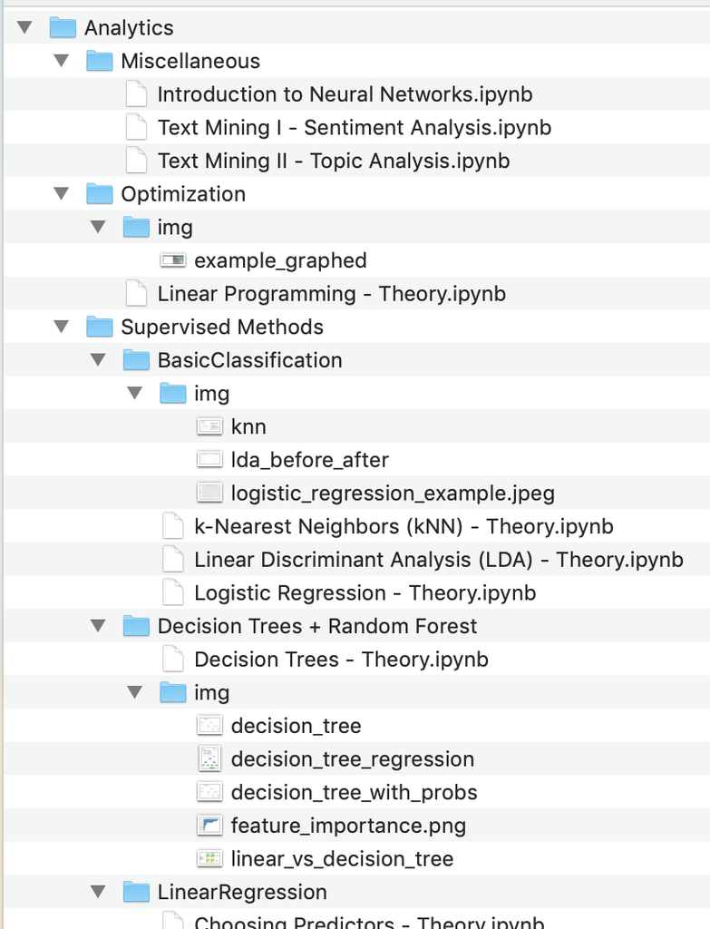

```python
Image('img/file_systems_example.png')
```

This is a partial view of the file system for the Module II content.

This is the easiest and most straightforward type of database, which is suitable if you're just worrying about smaller .csv files, for example.

## SQL

**SQL** (Structured Query Language) is a language for communicating with databases, and is the standard language for relational database management systems.

Common relational database management systems include:

- Oracle
- Microsoft SQL Server
- MySQL
- PostGreSQL
- SQL Lite

Recall in the API portion the CRUD (Create, Read, Update, Delete) operations. CRUD operations are the core of standard SQL commands.

- **CREATE** - Create
- **SELECT** - Read
- **UPDATE/INSERT** - Update
- **DELETE/DROP** - Delete

### Relational Database

A relational datbase is a type of database that allows a user to identify and access data in relation to another piece of data in the database. It is typically organized into tables.

Relational databases are often described in schema like below:

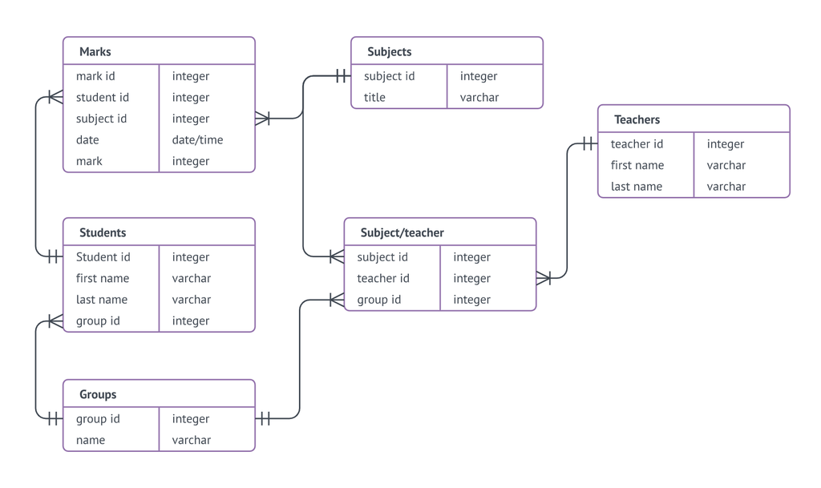

```python
Image('img/relational_schema_example.png')
```

Source: Lucidcharts

Breaking this down:

- Each box represents a table (which would like a spreadsheet if we viewed it)
  - The bolded header is the name of the table
  - The left column contains the data fields (the header row if we were to view this as spreadsheet)
  - The right column contains the data types for each field
- The lines connecting the tables together represent the relationship between tables
  - Note that tables are connected by matching ids
  - E.x. the "Subject/teacher" table and the "Teachers" table are related to each other by "teacher id"
    - Specifically it is saying that there is a "Many-to-One" relationship between Subject/Teacher and Teachers

### Relationships

There are three main kinds of relationships:

- One-to-One
- One-to-Many
- Many-to-Many

**One-to-One**

- A row in Table A can only have one matching row in Table B and vice versa

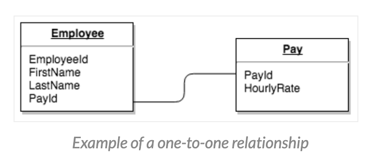

```python
Image("img/one-to-one.png")
```

Source: Database.Guide

**One-to-Many (or Many-to-One)**

- A row in Table A can have many matching rows in Table B but not vice versa
- A row in Table B can only have one matching row in A

In the relational_schema_example.png, all the relationships are one to many.

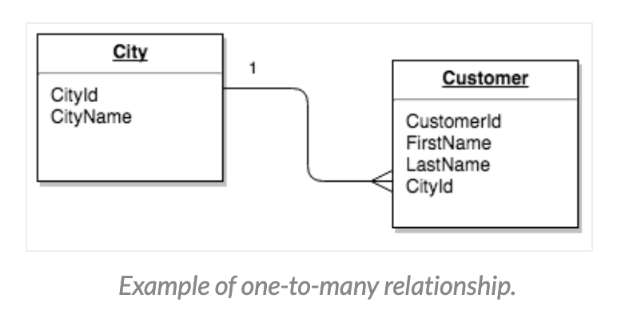

```python
Image("img/one-to-many.png")
```

Source: Database.Guide

**Many-to-Many**

- A row in Table A can have many matching rows in Table B and vice versa

[figure not shown]

```python
Image("img/many-to-many.png")
```

Source: Database.Guide

### Keys

There are different types of keys that come up in SQL:

- Super Key
- Primary Key
- Unique Key
- Alternate Key
- Candidate Key
- Composite/Compound Key
- Foreign Key

**Super Key**

- Set of one or more keys that can be used to identify a record/data uniquely in a table
- If we were to query on these keys, each value would be unique
- Primary Keys, Unique Keys, and Alternate Keys are subsets of Super Keys

**Primary Key**

- A set of one or more fields/columns of a table that unique identify a record in a table
  - E.x. First_Name, Last_Name, and Address could be a primary key for students in class
- Only one primary key can exist in a single table

**Unique Key**

- Set of one or more fields/columns of a table that have the ability to uniquely identify a record in a database table
- Fields beyond the primary key can be unique keys
  - E.x. Phone_Number could be a unique key from the previous students example
- Can accept only one NULL value and must not have any duplicate values

**Alternate Key**

- Recall we are only allowed one primary key
- An alternate key can work as a primary key if required
- Can be seen as a candidate for a primary key

**Candidate Key**

- Sets of fields/columns that can identify a record uniquely in a table like a primary key

**Composite/Compound Key**

- Combination of more than one fields/columns of a table to uniquely identify a record
  - E.x. We could combine First_Name and Last_Name into just Full_Name

**Foreign Key**

- A field/column in Table A that is a primary key in Table B

## SQL Joins

Often times, we will want information from more than one table. We can JOIN tables together in a number of different ways when we query data. Below are illustrations of SQL Joins between a Table A and a Table B.

- A SQL JOIN between Table A and Table B happens on the matching keys (remember the relationships and foreign keys!)

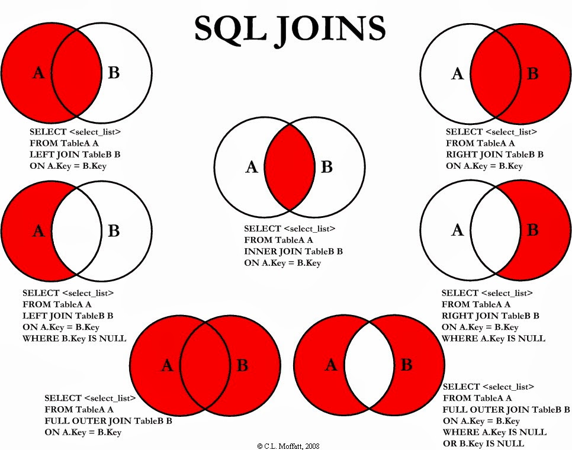

```python
Image('img/sql_joins.jpg')
```

Source: Java Revisited

## Common SQL Commands

### SELECT

```
select "column1"
  [,"column2",etc]
  from "tablename"
  [where "condition"];


  [] = optional
```

Examples:

```
SELECT YR, MO, PREC_mm, PET_mm, PET_mm-PREC_mm as PED_mm FROM watershed_monthly

SELECT * From watershed_monthly
```

- An *means "ALL" so ```SELECT* From watershed_monthly``` is saying to select all columns from the watershed_monthly table

### INSERT

```
insert into "tablename"
 (first_column,...last_column)
  values (first_value,...last_value);
```

Example:

```
insert into watershed_monthly
  (YR, MO, Prec_mm)
  values (2019,2,217);
```

### UPDATE

```
update "tablename"
set "columnname" =
    "newvalue"
 [,"nextcolumn" =
   "newvalue2"...]
where "columnname"
  OPERATOR "value"
 [and|or "column"
  OPERATOR "value"];

[] = optional
```

Example:

```
update watershed_monthly
  set YR = 2009
  where id = 100;
```

Here, we are setting the year to 2009 for all data with ID 100.

### DELETE

```
delete from "tablename"

where "columnname"
  OPERATOR "value"
[and|or "column"
  OPERATOR "value"];

[ ] = optional
```

Examples:

```
delete from watershed_monthly;

delete from watershed_monthly
  where year = 2009;
```

The first example deletes **all** data from watershed_monthly.

The second example deletes just 2009 data from watershed_monthly.

### JOIN

```
SELECT "list-of-columns"

FROM table1,table2

WHERE "search-condition(s)"


or


SELECT "list-of-columns"

FROM table1 JOIN_TYPE table2

WHERE "search-condition(s)"
```

Here, JOIN_TYPE can be something like INNER JOIN or LEFT JOIN. In the first example, the default is INNER JOIN.

You can also replace "WHERE" with "ON".

Example:

```
SELECT customer_info.firstname, customer_info.lastname, purchases.item

FROM customer_info INNER JOIN purchases

ON customer_info.customer_id = purchases.customer_id;
```

Here, customer_id is a foreign key that connects customer_info and purchases and we can do an inner join on this key.

## NoSQL

NoSQL databases are databases that store data in a format other than a relational table. There are four main types of NoSQL databases:

- Document Databases
- Key-Value Databases
- Wide-Column Stores
- Graph Databases

A common misconception is NoSQL databases cannot store relationship data.

- They can, just diffrently from relatoinal databases
- NoSQL data models allow related data to be nested within a single data structure rather than be split across tables

### Document Databases

- Store data in documents similar to JSON (Javascript Object Notation) objects
- Each document contains pairs of fields and values
- Many use cases, including as a general purpose database
- MongoDB is a popular document database

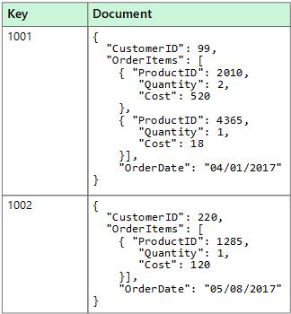

```python
Image('img/document_database_example.png')
```

Source: Microsoft Azure

### Key-Value Databases

- Each item contains keys and values (recall hashmap or dictionary data structures)
- Good if you need to store a lot of data but do not require complex queries
- Common use cases include storing user preferences or caching
- Redis and DynanoDB are popular key-value databases

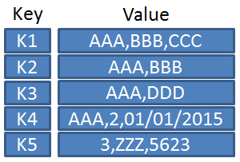

```python
Image('img/key_value_database.png')
```

Source: Wikipedia

### Wide-Column Stores

- Store data in tables, rows, and dynamic columns
- Each row is not required to have the same columns (more flexible than relational database)
- Good when you need to store large amounts of data and can predict what the query patterns will be
- Comonly used for IoT (Internet of Things) data and user profile data
- HBase and Cassandra are popular wide-column stores

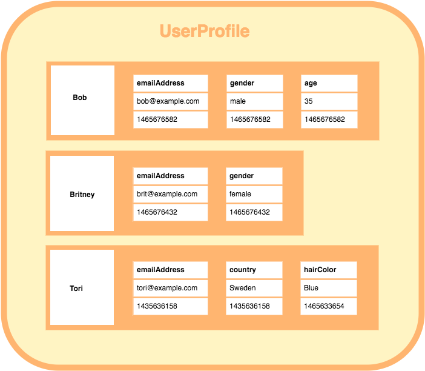

```python
Image("img/column_store_database.png")
```

Source: Database.Guide

### Graph Databases

- Store data in nodes and edges
- The nodes contain information about whatever person, place or thing is being described
- The edges contain information about the relationships between nodes
- Useful when you need to. traverse relatoinships for patterns (such as in social networks or recommendation engines)
- Neo4j and JanusGraph are popular graph databases

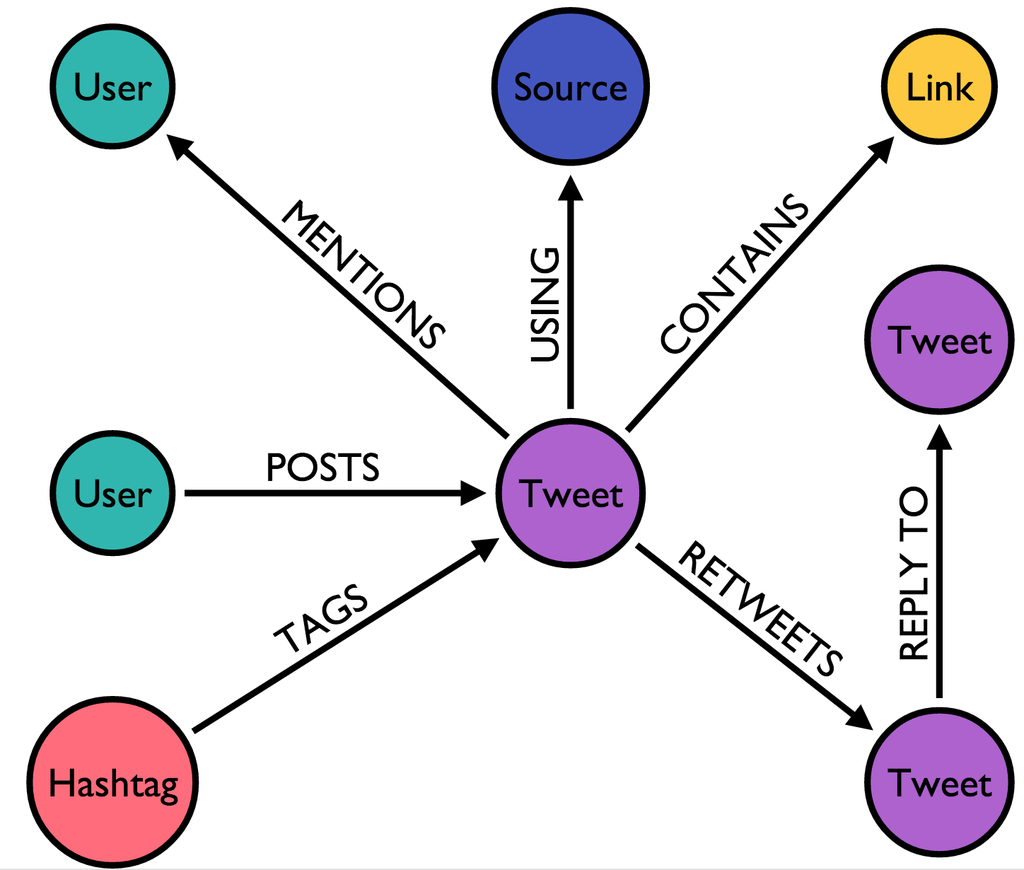

```python
Image("img/graph_database.png")
```

Source: Neo4j

## More Resources

[Cassandra Documentation](http://cassandra.apache.org/doc/latest/)

[Neo4j Documentation](https://neo4j.com/docs/)